Insights Into WeRateDogs Project

by Collins Kimotho

# Introduction

These insights were made after gathering data from the WeRateDogs Twitter account. The data was gathered from three sources, manual download, programmatic download and additional data was collected from Twitter API. After gathering the data, I immediately wanted to find out the most popular dog breed, the most popular dog stage and whether the ratings of a dog affect the number of retweets. To answer these questions, I used a number of python libraries and utilized my data analysis skills to come up with proper visualizations that can summarize my findings.

[figure not shown]

From my analysis, I came to the conclusion that dogs with a higher rating were more likely to be retweeted more than dogs with a low rating. I achieved this conclusion by identifying a median rating and querying this median to identify two group ratings, the high and low. The bar graph below confirms these insights.

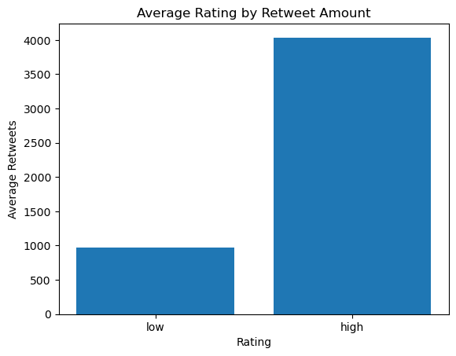

I also uncovered that the most liked and retweeted dog breed was the golden retriever followed by the Labrador retriever. Besides these two, other dogs that made it to the top five most retweeted and liked dogs were the Pembroke, Chihuahua and the Samoyed. However, even though the Golden Retriever was the most liked and retweeted dog breed, a Labrador Retriever held the number one spot for having the highest number of retweets and likes.

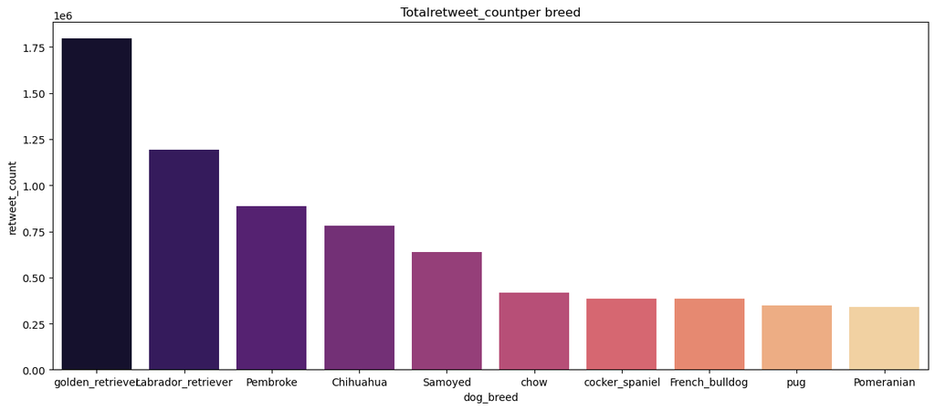

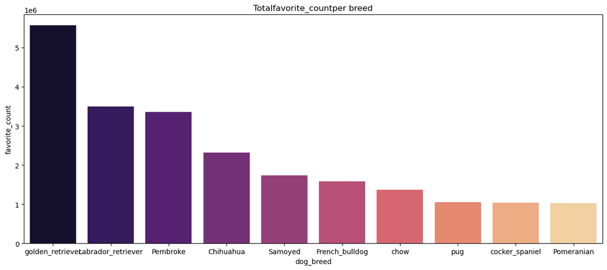

Finally, I wanted to identify the dog stages of each tweet or dog post. However, as my analysis provided, most tweeter users did not specify their dog’s stage. Only 14% of them did which was not enough to make further analysis. In conclusion, this data can be utilized for researchers and academics who wish to identify the most liked dog on Twitter and one that is most retweeted by Twitter users.

None 1968

pupper 212

doggo 73

puppo 23

floofer 8